# Analysis of UoA Student Commutes

## What’s going on with this data?

This report further explores commuting patterns for students at the University of Auckland travelling to and from the City Campus. The survey recorded three key aspects of each student’s commute. The time of the commute (in minutes), the mode of transport used (e.g. bus, walking, car), and the time of day the commute occurred.

The survey, and its further analysis, allowed us to follow students commuting habits, such as which transport methods are most commonly used, how commute times vary between transport modes, and when students are most likely to travel.

## The impact transport mode has

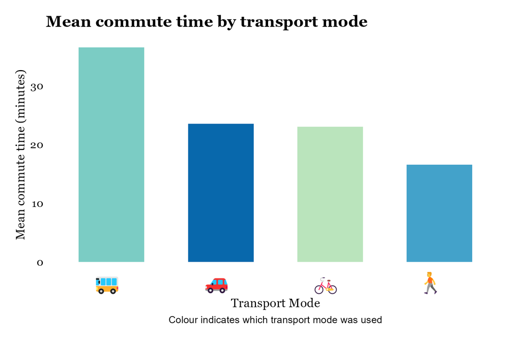

The plot indicates the mean commute time in minutes by transport mode. It shows bus having the highest mean commute time, followed by car and bicycle, who have equal value, and then walking, which has the lowest mean commute time.

Students who walk are more likely to live in on-campus accommodation, or at a walk-able distance away from City Campus, whereas students utilising bus, car and bike may live further from City Campus.

It is a shame that bus has the highest commute time, as for students, this is likely to be the most accessible and affordable transport option to university.

## Commute time over study period: Respondent behaviour

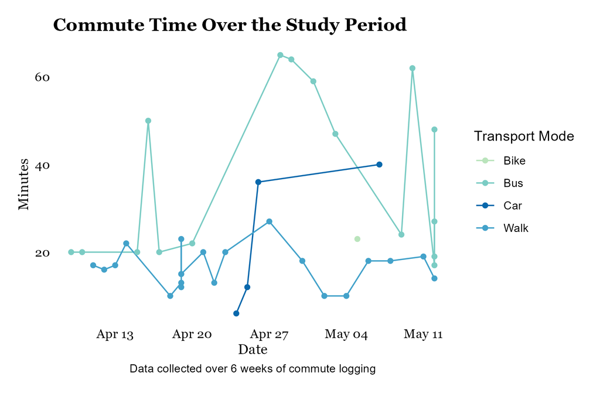

The plot indicates the commute time over the study period per transport mode. It shows a line graph connecting all the survey points for each transport mode.

This plot shows a line graph for each transport mode. The line connect dots for each survey point.

The plot indicates that car usage was not particularly present in the data set, only appearing just before halfway through the survey, and only with 4 points. This reflects travelling by car is not popular with the respondents. This could be due to traffic, parking costs, and other car-related costs.

Bike was utilised only once for the time duration of the survey, so instead of a line, presents a single dot. This means only once did a student use biking as a way to commute to uni. This is indicative of the respondents transport mode choices, habits or access to biking resources and safe bike routes.

Bus and walk were used consistently through the study, with walk presenting more frequently, and with lower commute times than bus. Bus presents two significant peak points, where the commute time is close to or at 60 minutes. This is probably due to the same student filling out the survey at different points.

## All together!!

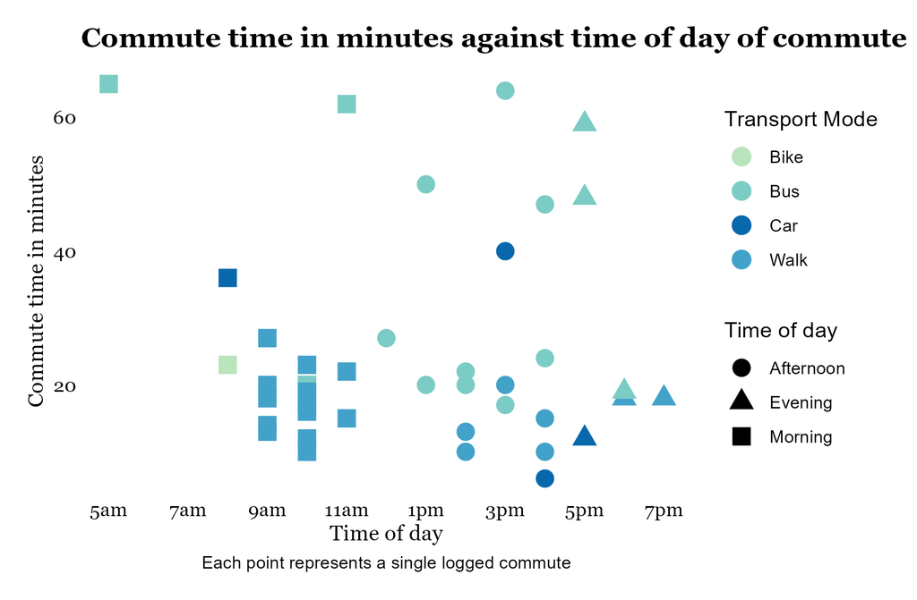

The highest commute times are still associated with buses, regardless of the time of day. They are also spread through the day, indicating the high commute time is not associated with a specific rush hour.

Most commutes, regardless of transport mode, appear to be between 15 and 30 minutes, which indicates most students who responded to the survey live a relatively similar distance from campus.

Walking appears to be the most time-consistent transport mode, with the three other categories having higher variability. Busing shows the most variability, making it the least predictable option for students trying to plan their day.

## Wrapping everything up

Overall, this analysis provides meaningful insight for students at the University of Auckland who commute to City Campus regularly. The findings could help students plan their daily journeys, or inform decisions about where to look for flats and student accommodation.

Beyond the individual level, this data offers a window into the broader University of Auckland student commuting experience, and could serve as useful input for those planning and improving campus transportation systems with the student experience in mind.